# FordGoBike - Tripdata

# Bivariate Exploration

# Question:

# Question

##### What is the relation between user_types and Average time.?

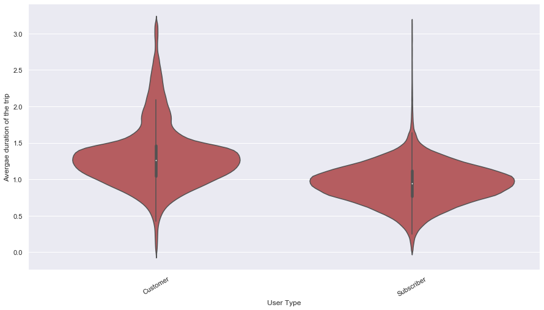

```python
# YOUR CODE HERE
plt.figure(figsize=(15,8))
base_color = sb.color_palette()[3]
sb.violinplot(data = df, x = 'user_type', y = 'log_duration_min',color = base_color)
plt.xticks(rotation = 30)
plt.xlabel('User Type')
plt.ylabel('Avergae duration of the trip');
```

# Question

##### What is the relation between average duration and the all the catergorical variables(Hire day , Hire month , User type)

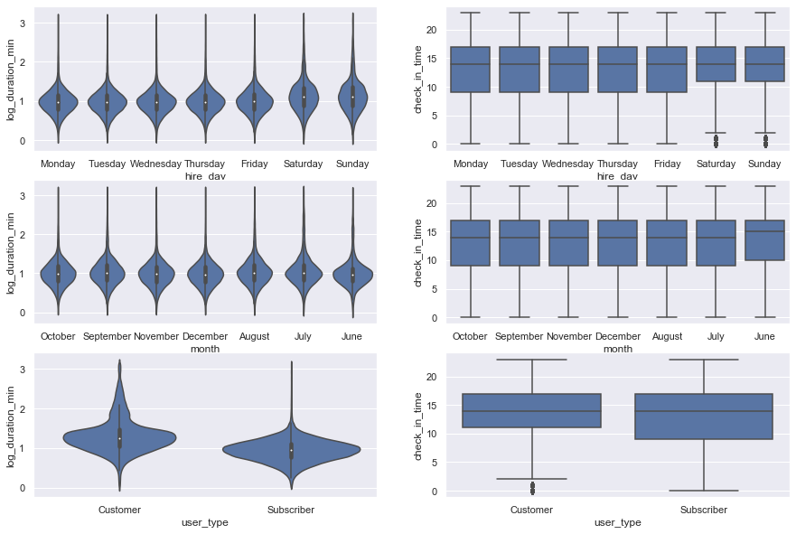

```python
# plot the categorical variables against duration_min and  again, this time
# with full data and variable transforms
fig, ax = plt.subplots(ncols = 2, nrows = 3 , figsize = [15,10])
default_color = sb.color_palette()[0]
for i in range(len(categoric_vars)):
    var = categoric_vars[i]
    sb.violinplot(data = new_df, x = var, y = 'log_duration_min', ax = ax[i,0], color = default_color);
    #ax[i,0].set_yticks(log_trans(np.array([1, 2, 5, 10, 20, 50, 100,500,1000])));
    #ax[i,0].set_yticklabels([1, 2, 5, 10, 20, 50, 100,500,1000]);
    sb.boxplot(data = new_df, x = var, y = 'check_in_time', ax = ax[i,1], color = default_color);
```

# Insights

> - **From the above charts the transformation of the average depicts clearly that subscribers use the service less than the customers. (i.e) Their average time is less when comapred to the Customers.**
> - **In my point of view the violin plot say that the avergae time for all month are almost equal.**
> - **Thirdly the average time for the weedays is same when comapared to the weekends there is slight variation which is more than the weekdays.**
> - **Speaking about the wiht respect to the Check in time it is clear that Customers tend to use the service between 11:00 hrs - 17:00 hrs while the subscribers tend to use the service between 8:00 hrs - 17:00 hrs.**
> - **Preferred time to use the service for all the month is almost equal while in june we can see a slight variation.**
> - **Preferred time to use the service for the weekdays is almost equal but we can see a variations in sunday and saturday.**

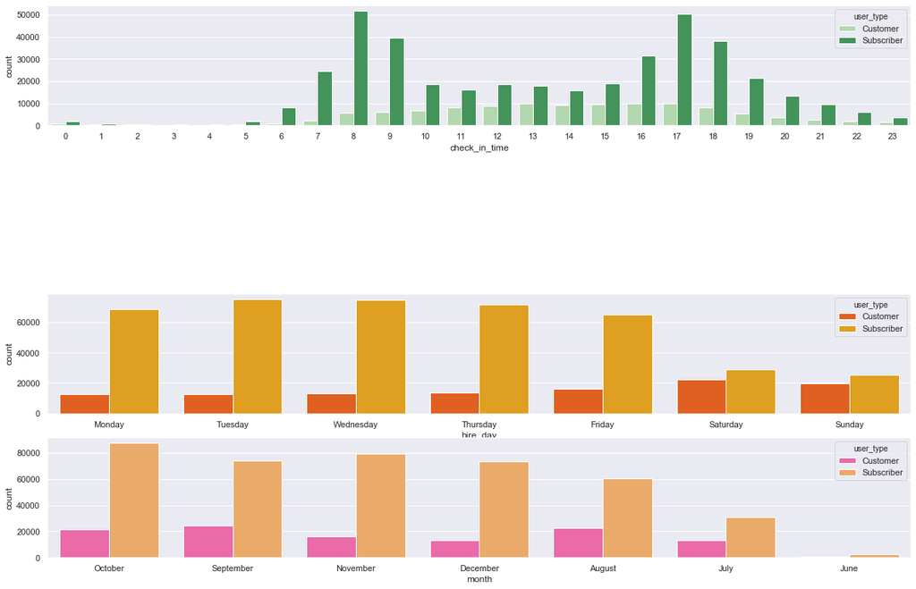

```python
plt.figure(figsize = [20, 20]);



ax = plt.subplot(6, 1, 3);
sb.countplot(data = new_df, x = 'check_in_time', hue = 'user_type', palette = 'Greens');
#ax.legend(loc = 1, ncol = 2); # re-arrange legend to remove overlapping


ax = plt.subplot(6, 1, 5);
sb.countplot(data = new_df, x = 'hire_day', hue = 'user_type', palette = 'autumn');

ax = plt.subplot(6, 1, 6);
sb.countplot(data = new_df, x = 'month', hue = 'user_type', palette = 'spring');
```

# Insights

> - **As we know company posses almost 78% of the subscribers the above charts shows that the subscribers are dominant across days,months and time of the day.**
> - **But we can see that the on Saturday and sundays the customers and subscribres have almost equal share in hiring the service.**

# Multivariate Exploration

# Question

### What is the Average time per day for each month

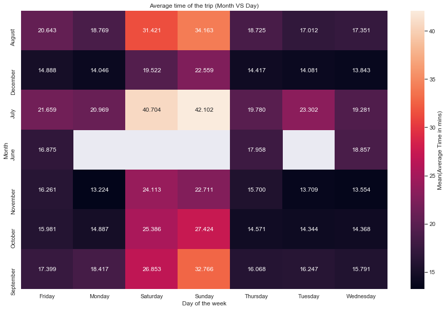

```python
# we will now plot the heat map

plt.figure(figsize=(16,10))
sb.heatmap(time_means, annot = True, fmt = '.3f',
           cbar_kws = {'label' : 'Mean(Average Time in mins)'})
plt.xlabel('Day of the week')
plt.ylabel('Month')
plt.title('Average time of the trip (Month VS Day)');
```

# Insight

> - **From the above Heat map we can see that the saturday and sunday has the High average time in the week.**
> - **And it is surprising because we noticed in the previous graphs that the Tuesday and Wednesday are the most preferred day for the user to pick the services from the company,but they tend to use the service for longer time in Saturday nad Sunday.**
> - **As we already know that the months October and September are the most preferred months for the users but every month they tend to use the services for longer times on Saturdays and Sundays.**

# Question

### Which time do the Users prefer to use the services of the company each day.

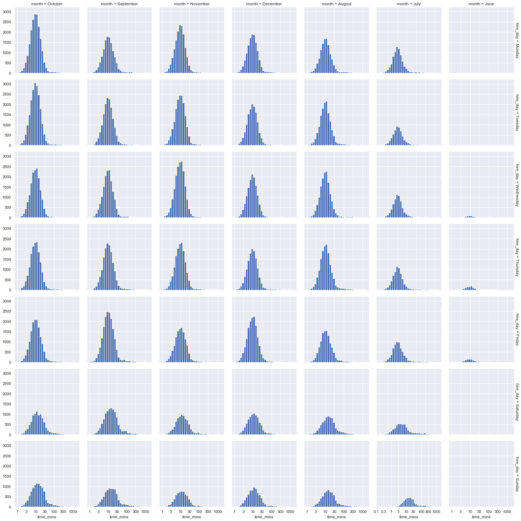

```python
# Construct the Facet grid
g = sb.FacetGrid(new_df, row = 'hire_day',col = 'month',margin_titles = True)
g = g.map(histogram_time_mins, 'time_mins')
```

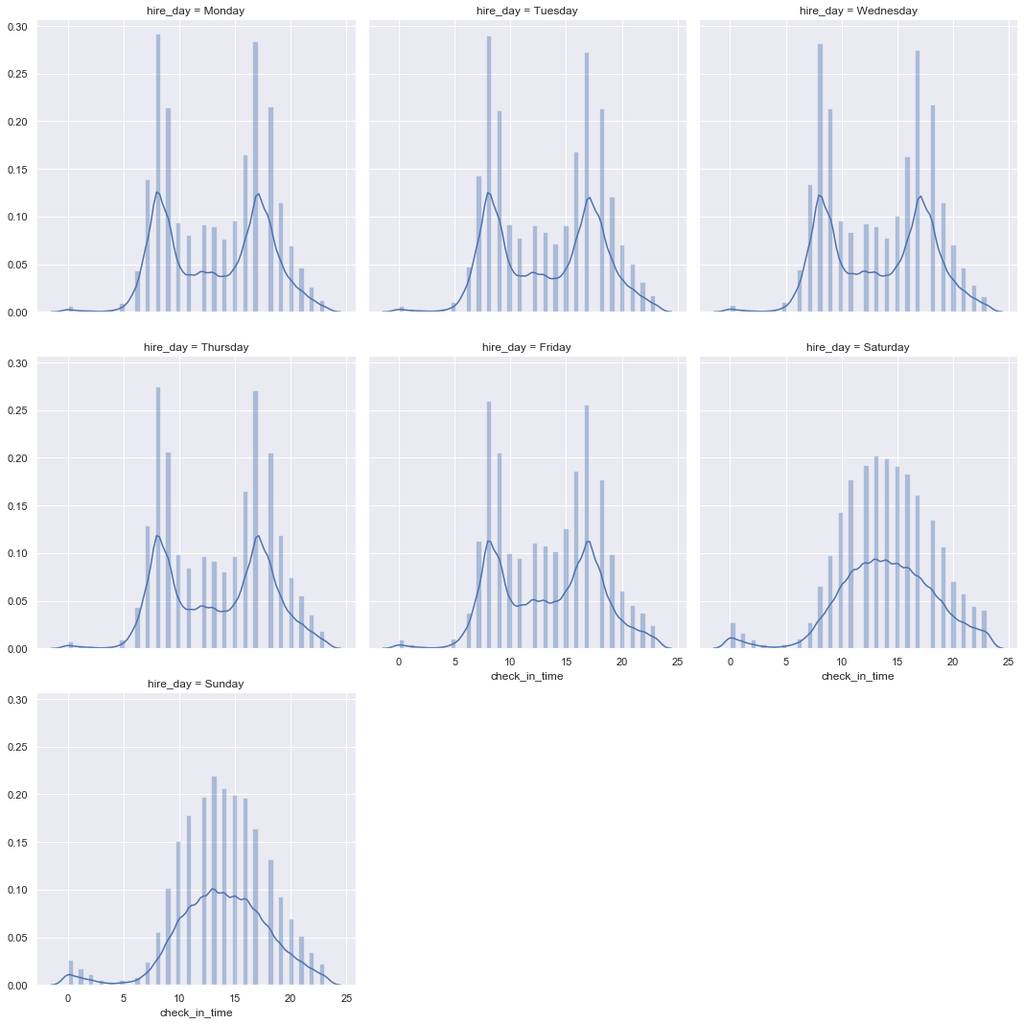

```python
g = sb.FacetGrid(data = new_df, col = 'hire_day',col_wrap = 3, height = 5,aspect = 1)
g.map(distplot_time_day,"check_in_time");
```

# Insights

> - **From the above Distplot we can see that the Saturday and Sunday the users tend to use the services between 10:00 hrs - 20:00 hrs.**
> - **And in weekdays the users tend to use the service more between 6:00 hrs - 10:00 hrs & 15:00 hrs - 19:00 hrs.**

```python
! jupyter nbconvert "Udacity final project resubmission.ipynb" --to slides --post serve --template output_toggle
```

[output not shown]